# Blue Granite R Demo

Author: Andy Lathrop, BlueGranite, Inc.

Date: 2016-06-27

Use the floating **table of contents on the left** for navigation, and **gray boxes on the right** to show/hide code

# 1 admin notes

## 1.1 about

Blue granite R Demo

Built with **Microsoft R Open** version 3, 2.5, 1. More info at https://mran.revolutionanalytics.com/open/

The current CRAN repository for this R session is https://mran.microsoft.com/snapshot/2016-05-01

The current default MRAN repository can be found at https://mran.revolutionanalytics.com/timemachine/

## 1.2 **rmarkdown** package required

This is an R markdown (.Rmd) document and requires the **‘rmarkdown’** package.

Use the tabs in this section for installation information.

More info at http://rmarkdown.rstudio.com/

## 1.3 **rmarkdown** installation

If you are working within RStudio then you can simply install the current release of RStudio (both the rmarkdown package and pandoc are included) https://www.rstudio.com/products/rstudio/download/

The code below will install the ‘rmarkdown’ package if needed

```r
if (!require("rmarkdown")) install.packages("rmarkdown"
                                            , repos='https://cran.revolutionanalytics.com')
library(rmarkdown)
```

**rmarkdown** global setup options  
Setup options: echo means R code will be displayed | cache means results will be stored for future knits

```r
knitr::opts_chunk$set(cache = TRUE,
                      echo  = TRUE)
options(scipen=1, digits=4)
```

## 1.4 package management

This section manages all packages required for this script.

The ‘p_load()’ function from the pacman package is the base equivalent of ‘install.packages()’ AND ‘library()’

```r
# ensure package 'pacman' for package management is installed
if (!require("pacman")) install.packages("pacman")
```

```r
library(pacman)

# add any required packages to the p_load() function parameters
pacman::p_load(rmarkdown # markdown functionality
               , knitr        # for table formatting
               , dplyr        # for data wrangling
               , memisc       # for convenient control structures like 'case'
               , ggplot2      # for better visualizations
               , ggthemes     # color themes for ggplot2
               , ggsci        # Scientific Journal and
                              # Sci-Fi Themed Color Palettes
               , grid         # enhance ggplot2
               , gridExtra    # enhance ggplot2
               , corrplot     # for corrleation plots
               , reshape2     # for data wrangling
               , randomForest # machine learning pkg
               , tree         # regression tree
               , dendextend   # for hierarchical clustering
               , cluster      # for clustering
               , amap         # for clustering
               , fclust       # for fuzzy clustering
               , factoextra   # fancy cluster plots
               , fpc          # cluster stats
               , mclust       # advanced clustering
               , plyr         # data wrangling
               , update=FALSE)
pacman::p_loaded() # check which packages are loaded
```

```
##  [1] "plyr"          "mclust"        "fpc"           "factoextra"
##  [5] "fclust"        "amap"          "cluster"       "dendextend"
##  [9] "tree"          "randomForest"  "reshape2"      "corrplot"
## [13] "gridExtra"     "ggsci"         "ggthemes"      "ggplot2"
## [17] "memisc"        "MASS"          "lattice"       "dplyr"
## [21] "knitr"         "pacman"        "rmarkdown"     "RevoUtilsMath"
```

# 2 data access and cleaning

## 2.1 data access

```r
getwd() # current working directory
```

```
## [1] "C:/Users/AndyLathrop/OneDrive - BlueGranite/Sales-and-Marketing/Webinars/JUN2016 Advanced Analytics MSFT R/1-analysis"
```

```r
data("iris")
dfS <- data.frame(cbind(scale(iris[1:4]), (iris[,"Species"]))) # scaled data frame
dfS <- dplyr::select(dfS, c(feature1 = Sepal.Length
                            , feature2 = Sepal.Width
                            , feature3 = Petal.Length
                            , feature4 = Petal.Width
                            , cluster  = V5))

dfS$cluster <- as.factor(dfS$cluster)

rm(iris)
```

# 3 function definitions

## 3.1 fn visualizations

### 3.1.1 viz fn MultiPlot pairs plot

```r
# This code creates a correlation matrix with r and p values
# Code from: http://bit.ly/24hV4Xz
# Help page for the function pairs() gives you example how to define panels to plot.

panel.cor <- function(x, y, digits=2, cex.cor) {
  usr          <- par("usr"); on.exit(par(usr))
  par(usr = c(0, 1, 0, 1))
  r            <- abs(cor(x, y))
  txt          <- format(c(r, 0.123456789), digits=digits)[1]
  test         <- cor.test(x,y)
  Signif       <- ifelse(round(test$p.value,3) < 0.001,
                         "p<0.001",
                         paste("p=", round(test$p.value,3))
                         )
  #text(0.5, 0.25, paste("r=",txt))
  if(missing(cex.cor)) cex.cor <- 0.8/strwidth(txt)
  text(0.5, 0.25, txt, cex = cex.cor * (1 + r) /3)
  text(.5, .75, Signif)
}

# For panel.smooth() function defined cex=, col= and pch= arguments.
panel.smooth <- function (x, y, col = "cornflowerblue", bg = NA, pch = 18,
                        cex = 0.8, col.smooth = "red", span = 2/3, iter = 3, ...) {
  points(x, y, pch = pch, col = col, bg = bg, cex = cex)
  ok <- is.finite(x) & is.finite(y)
  if (any(ok))
    lines(stats::lowess(x[ok], y[ok], f = span, iter = iter),
          col = col.smooth, ...)
}

# To add histograms, panel.hist() functions should be
# defined (taken from help file of pairs())
panel.hist <- function(x, ...) {
  usr <- par("usr"); on.exit(par(usr))
  par(usr = c(usr[1:2], 0, 1.5) )
  h <- hist(x, plot = FALSE)
  breaks <- h$breaks; nB <- length(breaks)
  y <- h$counts; y <- y/max(y)
  rect(breaks[-nB], 0, breaks[-1], y, col="coral", ...)
}

# pairs plot of distribution, scatter, r, and p-values between variables
MultiPlot <- function(myCols, myMain) {
  pairs(dfS[, myCols],
        lower.panel=panel.smooth, upper.panel=panel.cor,
        diag.panel=panel.hist, main= myMain)
}
```

### 3.1.2 viz fn CorrPlot correlation matrix

```r
# create correlation matrix
# from R Graphics Cookbook

CorrPlot <- function(myCols, order, myTitle) {

  d.cor <- dfS[, myCols]

  mcor <- cor(d.cor, use = "complete.obs")
  mcor <- round(mcor, digits=2)

  # generate a lighter color palette
  col <- colorRampPalette(c("#BB4444", "#EE9988", "#FFFFFF", "#77AADD", "#4477AA"))

  # order   parameter options
  # the ordering method of the correlation matrix.
  # "original" for original order (default).
  # "AOE" for the angular order of the eigenvectors.
  # "FPC" for the first principal component order.
  # "hclust" for the hierarchical clustering order.
  # "alphabet" for alphabetical order.

  # plot using corrplot package
  corrplot(mcor,
           method="shade",
           shade.col=NA,
           tl.col="black",
           tl.srt=20,
           col=col(200),
           addCoef.col="black",
           addCoefasPercent = TRUE,
           order=order,
           type="lower",
           tl.cex = .90,
           cl.cex = 0.90,
           pch.cex = 0.5,
           title = title(myTitle, line = -1)
           )
}
```

```r
# barplot
# legend location may  be specified by setting x to a single keyword from the list
# "bottomright", "bottom", "bottomleft", "left", "topleft", "top", "topright", "right"
# and "center".
myBarplot <- function(myCenters, k, title) {
  barplot(t(myCenters)
          , beside = TRUE
          , xlab="cluster"
          , ylab="value"
          , legend.text = TRUE
          , col = 2:6
          , args.legend = list(x = "bottom")
          , main = title)
}

# CreateDenPlot to create a density plot (smooth histogram), with params
#   myData  : data frame (e.g. metal)
#   xString : string vector of variable name to use for
#             x axis of density plot (e.g. "Mill.Head.FeCuR..")
#   myFill  : string vector of variable to use for fill (multiple series)
#             (e.g. "CuCluster")
CreateDenPlot <- function(myData, xString, myFill) {
  ggplot(myData, aes_string(x = xString, fill = myFill, colour=myFill)) +
    geom_density(alpha = 0.3) +
    theme_bw() +
    theme(legend.position="bottom") +
    scale_color_jco() +
    scale_fill_jco() +
    theme(axis.title.x = element_blank()) +
    ggtitle(paste0(xString, collapse = NULL))
}
```

### 3.1.3 viz fn cluster plots

```r
# function CreateBoxPlot is boxplot with following params
#  myData       : data frame
#  xString      : string vector of variable name to use for
#                 x axis of box plot (e.g. "cluster")
#  yString      : string value  of variable name to use for
#                 y axis of box plot (e.g. "feature1")
CreateBoxPlot <- function(myData, xString, yString) {
  ggplot(myData,
         aes_string(x = xString
           , y = yString
           , colour = xString
           , fill = xString)) +

  geom_boxplot(notch          = FALSE
               , width        = 0.50
               , outlier.size = 3
               , lwd          = .90
               , fatten       = 0
               , alpha        = 0.3) +

  stat_summary(fun.y   = "mean"
               , geom  = "point"
               , shape = 20
               , size  = 4
               , fill  = "white") +

  stat_summary(fun.y    = "mean"
               , geom   = "text"
               , vjust  = -1.85
               , hjust  = 0.0
               , colour = "black"
               , aes(label = round(..y.., digits = 3))) +

  # stat_boxplot(geom = "errorbar", lwd = 1, width = 0.5) +

  theme_bw() +
  scale_fill_jco() +
  scale_color_jco() +
  theme(legend.position = "right") +
  theme(axis.title.x = element_blank()) +
  theme(axis.title.y = element_blank()) +
  ggtitle(paste0(yString, collapse = NULL))
}

# grid_arrange_shared_legend helper function to create gtable object of
# multiple plots with one legend at the bottom, with parameters
#   ... : ggplot objects (multiple plot objects)
grid_arrange_shared_legend <- function(..., position = c("bottom", "right")) {

  plots <- list(...)
  position <- match.arg(position)
  g <- ggplotGrob(plots[[1]] + theme(legend.position=position))$grobs
  legend <- g[[which(sapply(g, function(x) x$name) == "guide-box")]]
  lheight <- sum(legend$height)
  lwidth <- sum(legend$width)
  gl <- lapply(plots, function(x) x + theme(legend.position="none"))

  combined <- switch(position,
                     "bottom" = arrangeGrob(do.call(arrangeGrob, gl),
                                            legend,
                                            ncol = 1,
                                            heights = unit.c(unit(1, "npc") - lheight, lheight)),
                     "right" = arrangeGrob(do.call(arrangeGrob, gl),
                                           legend,
                                           ncol = 2,
                                           widths = unit.c(unit(1, "npc") - lwidth, lwidth)))

  grid.newpage()
  # grid.draw(combined) # original code, draws the plot (but I want an object)
  arrangeGrob(combined) # this returns a gtable object
}

# CreateDenPlot to create a density plot (smooth histogram), with params
#   myData  : data frame (e.g. metal)
#   xString : string vector of variable name to use for
#             x axis of density plot (e.g. "feature1")
#   myFill  : string vector of variable to use for fill (multiple series)
#             (e.g. "cluster")
CreateDenPlot <- function(myData, xString, myFill) {
  ggplot(myData, aes_string(x = xString, fill = myFill, colour=myFill)) +
    geom_density(alpha = 0.3) +
    theme_bw() +
    theme(legend.position="bottom") +
    scale_color_jco() +
    scale_fill_jco() +
    theme(axis.title.x = element_blank()) +
    ggtitle(paste0(xString, collapse = NULL))
}
```

# 4 exploratory data analysis

## 4.1 MultiPlot

**MultiPlot** is a pairs plot of distribution, scatter, r, and p-values between variables

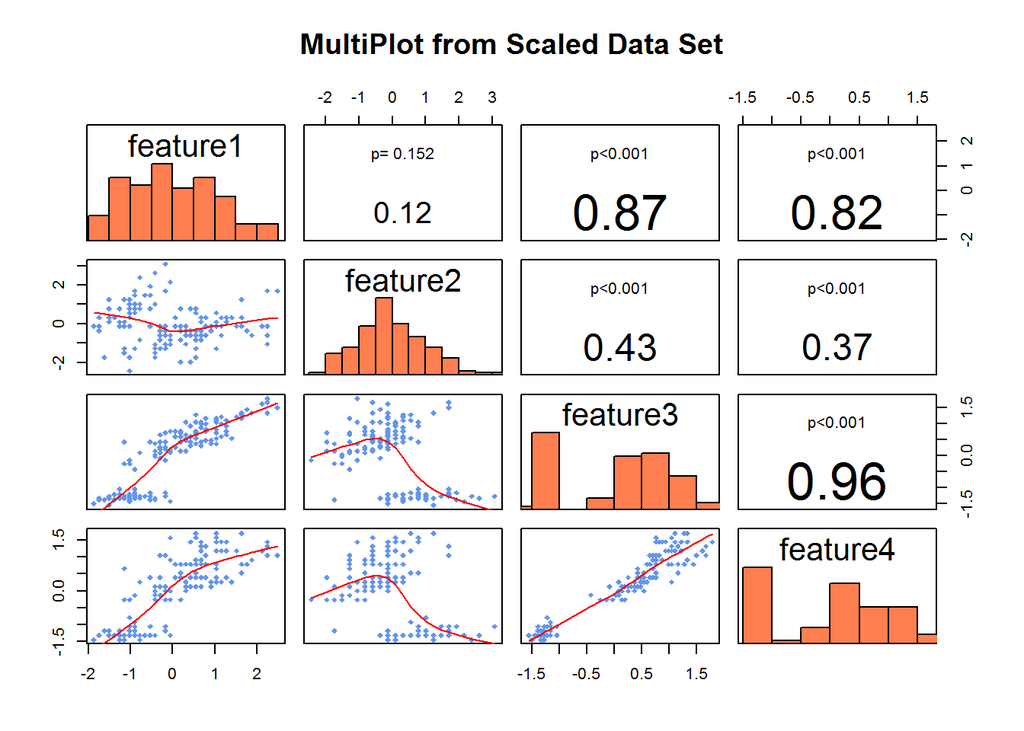

```r
# MultiPlot is a pairs plot of distribution,
# scatter, r, and p-values between variables

# MultiPlot function has params
#   myCols : columns to include in correlation matrix
#   myMain : plot title

MultiPlot(c("feature1", "feature2", "feature3", "feature4")
            ,  "MultiPlot from Scaled Data Set")
```

## 4.2 CorrPlot

**CorrPlot** is a correlation matrix

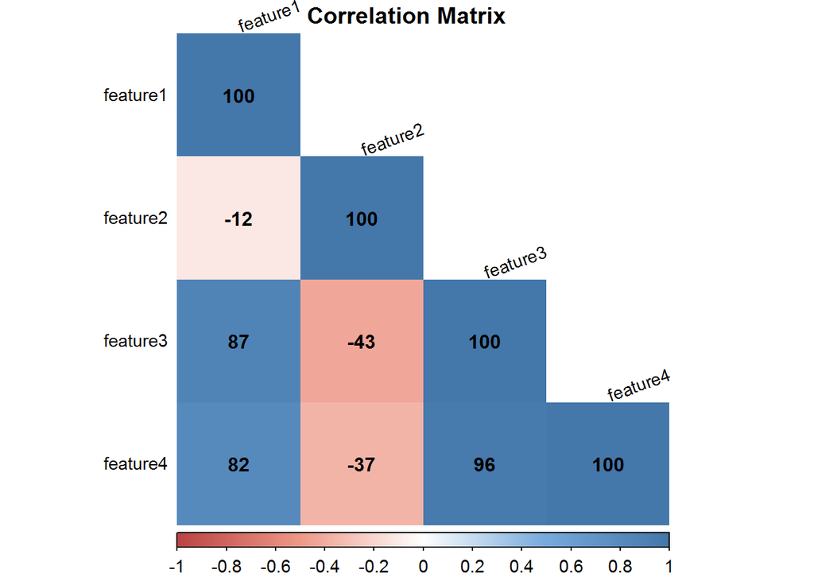

```r
# create correlation matrix

# CorrPlot function has params
#   myCOls  :  columns to include in correlation matrix
#   order   :  paramter to control ordering of cols in matrix, in quotes
#   myTitle :  chart title, in quotes

# order parameter options
# the ordering method of the correlation matrix.
# "original" for original order (default).
# "AOE" for the angular order of the eigenvectors.
# "FPC" for the first principal component order.
# "hclust" for the hierarchical clustering order.
# "alphabet" for alphabetical order.

order <- "original"
# par(mfrow=c(1,1)
#     # mar = c(0,0,2,0)
#     )

# features
dfSFeat <- c("feature1"
             , "feature2"
             , "feature3"
             , "feature4")

myCols <- c(dfSFeat)

# call plotting function
# break up plots b/c of so many variables
myTitle <- "Correlation Matrix"
CorrPlot(myCols
         , order
         , myTitle
         )
```

# 5 clustering

```r
set.seed(93)

# set # of clusters
k <- 3

# K means
fitKM <- kmeans(scale(dfS[,1:4]), iter.max = 500, k)
fitKM
```

```
## K-means clustering with 3 clusters of sizes 96, 21, 33
##
## Cluster means:
##   feature1 feature2 feature3 feature4
## 1   0.5691  -0.3705   0.6888   0.6609
## 2  -1.3232  -0.3719  -1.1334  -1.1111
## 3  -0.8135   1.3146  -1.2825  -1.2156
##
## Clustering vector:
##   [1] 3 2 2 2 3 3 3 3 2 2 3 3 2 2 3 3 3 3 3 3 3 3 3 3 3 2 3 3 3 2 2 3 3 3 2
##  [36] 2 3 3 2 3 3 2 2 3 3 2 3 2 3 3 1 1 1 1 1 1 1 2 1 1 2 1 1 1 1 1 1 1 1 1
##  [71] 1 1 1 1 1 1 1 1 1 1 1 1 1 1 1 1 1 1 1 1 1 1 1 2 1 1 1 1 2 1 1 1 1 1 1
## [106] 1 1 1 1 1 1 1 1 1 1 1 1 1 1 1 1 1 1 1 1 1 1 1 1 1 1 1 1 1 1 1 1 1 1 1
## [141] 1 1 1 1 1 1 1 1 1 1
##
## Within cluster sum of squares by cluster:
## [1] 149.26  23.16  17.33
##  (between_SS / total_SS =  68.2 %)
##
## Available components:
##
## [1] "cluster"      "centers"      "totss"        "withinss"
## [5] "tot.withinss" "betweenss"    "size"         "iter"
## [9] "ifault"
```

```r
summary(fitKM)
```

```
##              Length Class  Mode
## cluster      150    -none- numeric
## centers       12    -none- numeric
## totss          1    -none- numeric
## withinss       3    -none- numeric
## tot.withinss   1    -none- numeric
## betweenss      1    -none- numeric
## size           3    -none- numeric
## iter           1    -none- numeric
## ifault         1    -none- numeric
```

```r
table(fitKM$cluster) # num obs by cluster
```

```
##
##  1  2  3
## 96 21 33
```

```r
fitKM$centers # center of cluster
```

```
##   feature1 feature2 feature3 feature4
## 1   0.5691  -0.3705   0.6888   0.6609
## 2  -1.3232  -0.3719  -1.1334  -1.1111
## 3  -0.8135   1.3146  -1.2825  -1.2156
```

```r
# medoids
# PAM (partitioning around medoids)
fitPAM <- cluster::pam(dfS[,1:4], k)
fitPAM
```

```
## Medoids:
##       ID feature1 feature2 feature3 feature4
## [1,]   8  -1.0184   0.7862  -1.2791  -1.3111
## [2,] 113   1.1553  -0.1315   0.9868   1.1816
## [3,]  56  -0.1731  -0.5904   0.4203   0.1321
## Clustering vector:
##   [1] 1 1 1 1 1 1 1 1 1 1 1 1 1 1 1 1 1 1 1 1 1 1 1 1 1 1 1 1 1 1 1 1 1 1 1
##  [36] 1 1 1 1 1 1 1 1 1 1 1 1 1 1 1 2 2 2 3 3 3 2 3 3 3 3 3 3 3 3 2 3 3 3 3
##  [71] 3 3 3 3 3 2 2 2 3 3 3 3 3 3 3 3 2 3 3 3 3 3 3 3 3 3 3 3 3 3 2 3 2 2 2
## [106] 2 3 2 2 2 2 2 2 3 2 2 2 2 2 3 2 3 2 3 2 2 3 3 2 2 2 2 2 3 3 2 2 2 3 2
## [141] 2 2 3 2 2 2 3 2 2 3
## Objective function:
##  build   swap
## 0.9205 0.8757
##
## Available components:
##  [1] "medoids"    "id.med"     "clustering" "objective"  "isolation"
##  [6] "clusinfo"   "silinfo"    "diss"       "call"       "data"
```

```r
summary(fitPAM)
```

```
## Medoids:
##       ID feature1 feature2 feature3 feature4
## [1,]   8  -1.0184   0.7862  -1.2791  -1.3111
## [2,] 113   1.1553  -0.1315   0.9868   1.1816
## [3,]  56  -0.1731  -0.5904   0.4203   0.1321
## Clustering vector:
##   [1] 1 1 1 1 1 1 1 1 1 1 1 1 1 1 1 1 1 1 1 1 1 1 1 1 1 1 1 1 1 1 1 1 1 1 1
##  [36] 1 1 1 1 1 1 1 1 1 1 1 1 1 1 1 2 2 2 3 3 3 2 3 3 3 3 3 3 3 3 2 3 3 3 3
##  [71] 3 3 3 3 3 2 2 2 3 3 3 3 3 3 3 3 2 3 3 3 3 3 3 3 3 3 3 3 3 3 2 3 2 2 2
## [106] 2 3 2 2 2 2 2 2 3 2 2 2 2 2 3 2 3 2 3 2 2 3 3 2 2 2 2 2 3 3 2 2 2 3 2
## [141] 2 2 3 2 2 2 3 2 2 3
## Objective function:
##  build   swap
## 0.9205 0.8757
##
```

[output cut: 170 more lines]

```r
table(fitPAM$clustering)
```

```
##
##  1  2  3
## 50 45 55
```

```r
fitPAM$medoids # center of cluster
```

```
##      feature1 feature2 feature3 feature4
## [1,]  -1.0184   0.7862  -1.2791  -1.3111
## [2,]   1.1553  -0.1315   0.9868   1.1816
## [3,]  -0.1731  -0.5904   0.4203   0.1321
```

```r
# FKM w medoids and noise (fuzzy clustering)
fitPAM.n <- FKM.med.noise(dfS[,1:4]
                          , k = k
                          , m = 1.5
                          , delta = 4
                          , RS = 3)
table(fitPAM.n$clus[,1])
```

```
##
##  1  2  3
## 62 26 62
```

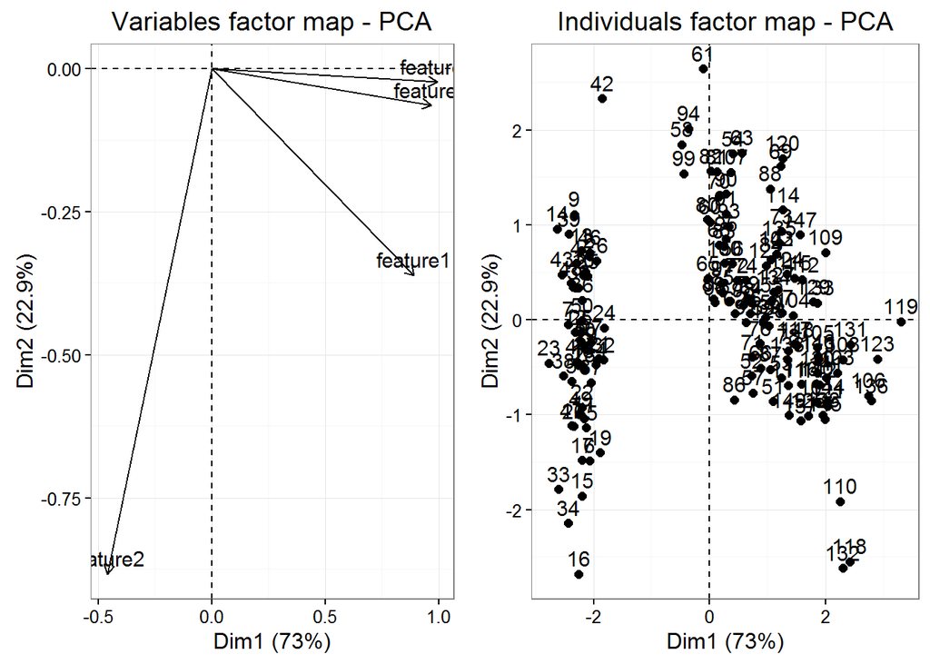

```r
# calc primary and seconday cluster assignment and probability
clusProbs              <- data.frame(round(fitPAM.n$U, 3)) # cluster probabilities
colnames(clusProbs)    <- paste("prob", colnames(clusProbs), sep = "_") # rename columns

clusProbs$primClus     <- fitPAM.n$clus[,1] # primary clster number
clusProbs$primClusProb <- round(fitPAM.n$clus[,2],3) # primary cluster probability

clusProbs$secClus      <- apply(clusProbs # secondary cluster
                                , 1
                                , function(x) which(rank(x, ties.method = "first")==3)) # secondary cluster

clusProbs$secClusProb  <- apply(clusProbs # secondary cluster probability
                                , 1
                                , function(x) x[which(rank(x, ties.method = "first")==3)]) # sec cluster prob

# table of results
dResults         <- dfS # initialize results table with original chem values
dResults         <- cbind(dResults, clusProbs)    # cluster membership; probability by cluster
dResults$tot     <- rowSums(round(fitPAM.n$U, 3)) # calc sum of probability across clusters
dResults$probOut <- round(1 - dResults$tot, 3)    # prob of being in outlier cluster

# calc principal components
myPrincomp <- prcomp(dfS[1:4])
# myPrincomp$x # matrix of principal component values
# plot prin comp
p1 <- fviz_pca_var(myPrincomp) +
  theme_bw()

p2 <- fviz_pca_ind(myPrincomp) +
  theme_bw()

grid.arrange(p1,p2, ncol = 2)
```

```r
dResults$prin1 <- round(myPrincomp$x[,1],4)
dResults$prin2 <- round(myPrincomp$x[,2],4)

# identify outliers (probability of being in the outlier cluster > 20%)
myOut <- which(dResults$probOut > 0.20)

# refit without outliers
fitPAM.n2 <- FKM.med.noise(dfS[-myOut,1:4]
                          , k = k
                          , m = 1.5
                          , delta = 3
                          , RS = 1)

fitPAM.n$medoid # which points are medoids
```

```
## [1]  65  96 148
```

```r
fitPAM.n$H # medoid center
```

```
##        feature1 feature2 feature3  feature4
## Clus 1  -0.2939  -0.3610  -0.0895 0.1320673
## Clus 2  -0.1731  -0.1315   0.2504 0.0008746
## Clus 3   0.7930  -0.1315   0.8169 1.0504160
```

```r
fitPAM.n$clus[1:150,] # which cluster assigned with associated probability
```

```
##     Cluster Membership degree
## 1         1            0.4455
## 2         1            0.5261
## 3         1            0.4909
## 4         1            0.5022
## 5         1            0.4276
## 6         2            0.4166
## 7         1            0.4646
## 8         1            0.4634
## 9         1            0.5082
## 10        1            0.5008
## 11        2            0.4239
## 12        1            0.4611
## 13        1            0.5094
## 14        1            0.4777
```

[output cut: 136 more lines]

```r
SIL(dfS[,1:4], fitPAM.n$U)
```

```
## $sil.obj
##    Obj 1    Obj 2    Obj 3    Obj 4    Obj 5    Obj 6    Obj 7    Obj 8
##  0.08740  0.49618  0.40253  0.46202  0.02074  0.26090  0.26428  0.20251
##    Obj 9   Obj 10   Obj 11   Obj 12   Obj 13   Obj 14   Obj 15   Obj 16
##  0.52347  0.44496  0.12260  0.23683  0.49499  0.48084  0.26804  0.31617
##   Obj 17   Obj 18   Obj 19   Obj 20   Obj 21   Obj 22   Obj 23   Obj 24
##  0.22747  0.07326  0.26678  0.12382  0.07723 -0.12993  0.12780  0.23821
##   Obj 25   Obj 26   Obj 27   Obj 28   Obj 29   Obj 30   Obj 31   Obj 32
##  0.22373  0.49126  0.17697  0.05151  0.15843  0.40256  0.45674  0.05951
##   Obj 33   Obj 34   Obj 35   Obj 36   Obj 37   Obj 38   Obj 39   Obj 40
##  0.21145  0.27077  0.44938  0.37339 -0.02583  0.05970  0.49444  0.17917
##   Obj 41   Obj 42   Obj 43   Obj 44   Obj 45   Obj 46   Obj 47   Obj 48
##  0.10687  0.53203  0.40901  0.03525  0.17518  0.50425  0.11488  0.40733
##   Obj 49   Obj 50   Obj 51   Obj 52   Obj 53   Obj 54   Obj 55   Obj 56
##  0.09729  0.29512  0.67822  0.60733  0.76188  0.02870  0.73449 -0.41133
##   Obj 57   Obj 58   Obj 59   Obj 60   Obj 61   Obj 62   Obj 63   Obj 64
##  0.59023  0.47563  0.67687  0.19734  0.36758 -0.47305 -0.07408 -0.63208
##   Obj 65   Obj 66   Obj 67   Obj 68   Obj 69   Obj 70   Obj 71   Obj 72
##  0.08986  0.65642 -0.38390 -0.00270 -0.46810  0.14205  0.58971 -0.45284
##   Obj 73   Obj 74   Obj 75   Obj 76   Obj 77   Obj 78   Obj 79   Obj 80
##  0.65518 -0.55647 -0.61271  0.67266  0.74967  0.82798 -0.60747  0.27565
##   Obj 81   Obj 82   Obj 83   Obj 84   Obj 85   Obj 86   Obj 87   Obj 88
##  0.21587  0.29329 -0.11303  0.69124 -0.27252 -0.36661  0.73427 -0.45382
##   Obj 89   Obj 90   Obj 91   Obj 92   Obj 93   Obj 94   Obj 95   Obj 96
## -0.14381  0.02774 -0.03644 -0.59111 -0.13590  0.46273 -0.14377 -0.15966
##   Obj 97   Obj 98   Obj 99  Obj 100  Obj 101  Obj 102  Obj 103  Obj 104
## -0.30166 -0.55306  0.46685 -0.20522  0.76791  0.68967  0.86032  0.83110
##  Obj 105  Obj 106  Obj 107  Obj 108  Obj 109  Obj 110  Obj 111  Obj 112
##  0.86474  0.80017 -0.01090  0.82827  0.79441  0.68712  0.81000  0.82277
##  Obj 113  Obj 114  Obj 115  Obj 116  Obj 117  Obj 118  Obj 119  Obj 120
##  0.87336  0.59784  0.72532  0.80973  0.85002  0.58286  0.76765 -0.46948
##  Obj 121  Obj 122  Obj 123  Obj 124  Obj 125  Obj 126  Obj 127  Obj 128
##  0.83769  0.62758  0.78492  0.77999  0.81092  0.80927  0.76790  0.74539
##  Obj 129  Obj 130  Obj 131  Obj 132  Obj 133  Obj 134  Obj 135  Obj 136
##  0.85193  0.81636  0.82307  0.55486  0.85058  0.74645  0.66811  0.79400
##  Obj 137  Obj 138  Obj 139  Obj 140  Obj 141  Obj 142  Obj 143  Obj 144
##  0.72687  0.82391  0.70390  0.85861  0.84995  0.84399  0.68967  0.83931
##  Obj 145  Obj 146  Obj 147  Obj 148  Obj 149  Obj 150
##  0.79699  0.85957  0.74271  0.85589  0.70150  0.69957
##
## $sil
## [1] 0.3604
```

```r
SIL.F(dfS[,1:4], fitPAM.n$U, 1)
```

```
## [1] 0.5445
```

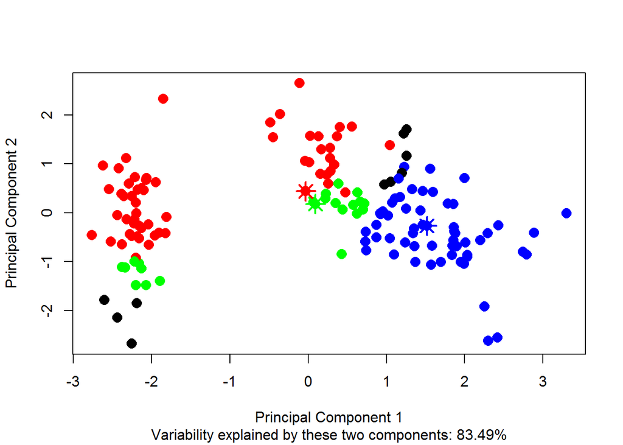

```r
plot.fclust(fitPAM.n
            , pca = TRUE
           #, ucex = TRUE # magnify by max membership
            , umin = 0.40) # membership threshhold
```

```r
                                    #for assignment to cluster
print.fclust(fitPAM.n)
```

```
##
##  Fuzzy clustering object of class 'fclust'
##
##  Number of objects:
##  150
##
##  Number of clusters:
##  3
##
##  Closest hard clustering partition:
##   1   2   3   4   5   6   7   8   9  10  11  12  13  14  15  16  17  18
##   1   1   1   1   1   2   1   1   1   1   2   1   1   1   2   2   2   1
##  19  20  21  22  23  24  25  26  27  28  29  30  31  32  33  34  35  36
##   2   2   1   1   1   1   1   1   1   1   1   1   1   1   2   2   1   1
##  37  38  39  40  41  42  43  44  45  46  47  48  49  50  51  52  53  54
```

[output cut: 172 more lines]

```r
summary(fitPAM.n)
```

```
##
##  Fuzzy clustering object of class 'fclust'
##
##  Number of objects:
##  150
##
##  Number of clusters:
##  3
##
##  Cluster sizes:
## Clus 1 Clus 2 Clus 3
##     62     26     62
##
##  Closest hard clustering partition:
##   1   2   3   4   5   6   7   8   9  10  11  12  13  14  15  16  17  18
```

[output cut: 217 more lines]